# NHL Shot Effectiveness Model

## Calgary Flames

Let’s get our data from the Neural Network and K-Nearest Neighbors algorithms.

```r
cgy.nnet = get.team.data(nnet.prediction.data, "CGY")
cgy.knn = get.team.data(knn.prediction.data, "CGY")
```

Let’s just visualize our shots type data.

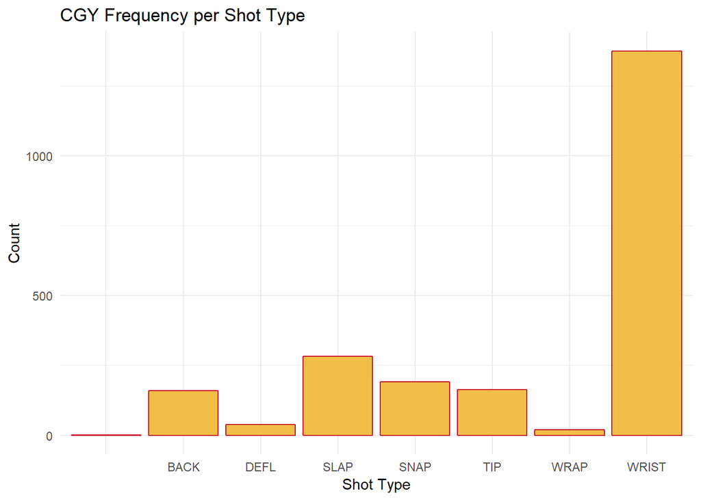

```r
cgy.type.freq = make.type.freq.plot(cgy.nnet, "#C8102E", "#F1BE48", "CGY")

cgy.type.freq
```

Here is how the Flames did with shots versus goal probability from the KNN model.

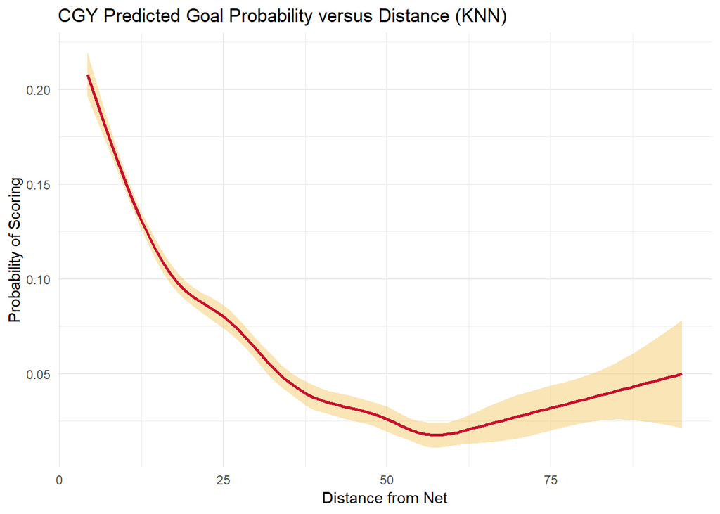

```r
cgy.knn.dist = make.knn.dist.plot(cgy.knn, "#C8102E", "#F1BE48", "CGY")

cgy.knn.dist
```

And now with the neural network.

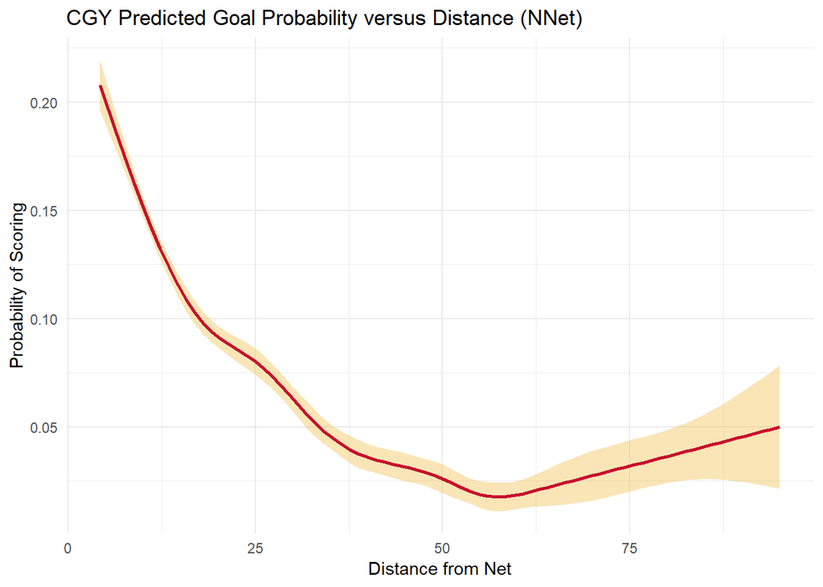

```r
cgy.nnet.dist = make.nnet.dist.plot(cgy.knn, "#C8102E", "#F1BE48", "CGY")

cgy.nnet.dist
```

Now let’s look at shot type versus goal probability.

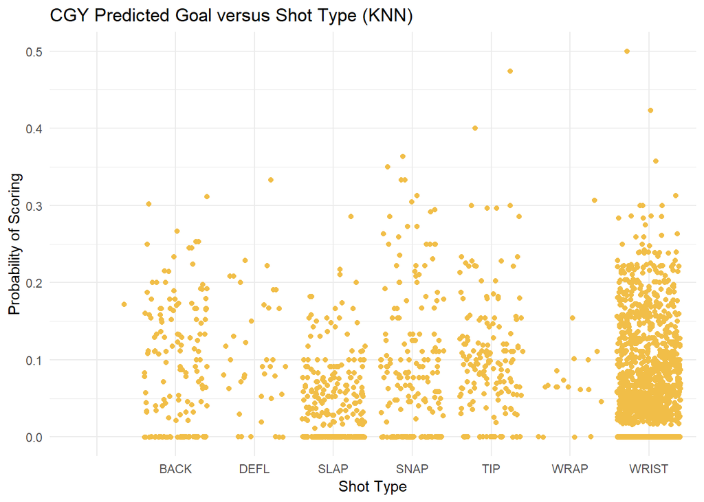

```r
cgy.knn.type = make.knn.type.plot(cgy.knn, "#C8102E", "#F1BE48", "CGY")

cgy.knn.type
```

And now with the neural network.

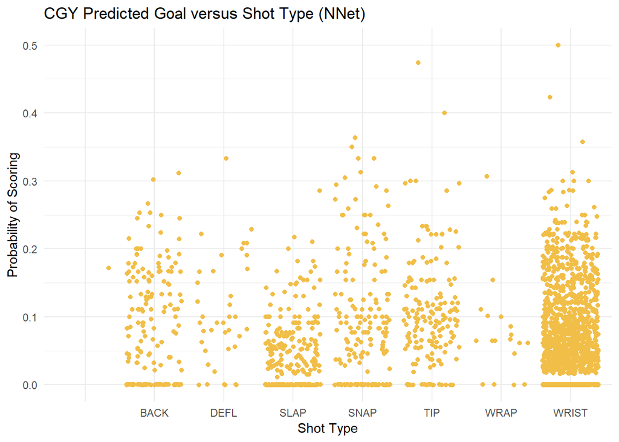

```r
cgy.nnet.type = make.nnet.type.plot(cgy.knn, "#C8102E", "#F1BE48", "CGY")

cgy.nnet.type
```

## New York Islanders

Let’s get our data from the Neural Network and K-Nearest Neighbors algorithms.

```r
nyi.nnet = get.team.data(nnet.prediction.data, "NYI")
nyi.knn = get.team.data(knn.prediction.data, "NYI")
```

Let’s just visualize our shots type data.

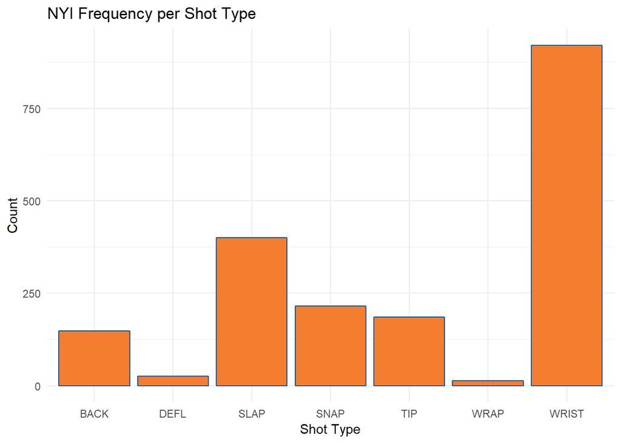

```r
nyi.type.freq = make.type.freq.plot(nyi.nnet, "#00539B", "#F47D30", "NYI")

nyi.type.freq
```

Here is how the Islanders did with shots versus goal probability from the KNN model.

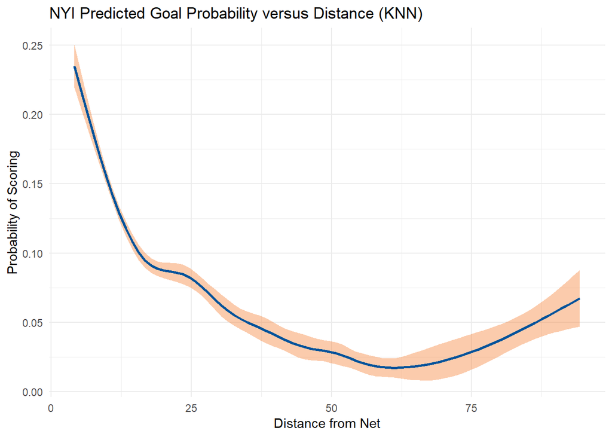

```r
nyi.knn.dist = make.knn.dist.plot(nyi.knn, "#00539B", "#F47D30", "NYI")

nyi.knn.dist
```

And now with the neural network.

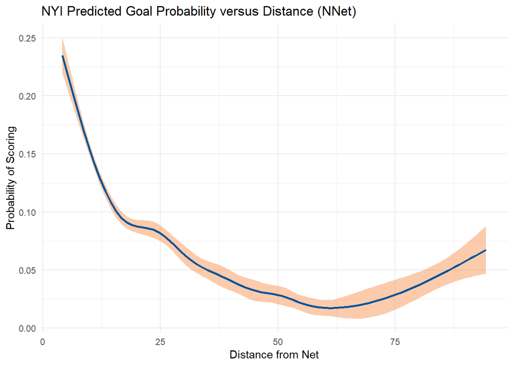

```r
nyi.nnet.dist = make.nnet.dist.plot(nyi.knn, "#00539B", "#F47D30", "NYI")

nyi.nnet.dist
```

Now let’s look at shot type versus goal probability.

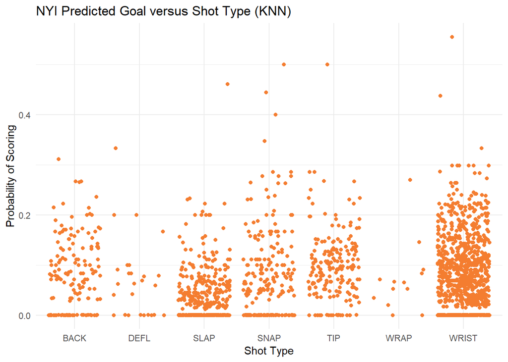

```r
nyi.knn.type = make.knn.type.plot(nyi.knn, "#00539B", "#F47D30", "NYI")

nyi.knn.type
```

And now with the neural network.

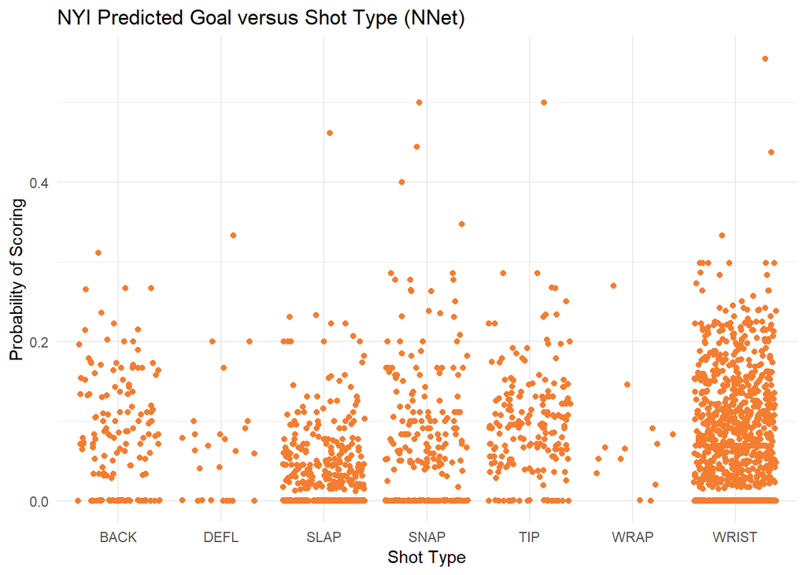

```r
nyi.nnet.type = make.nnet.type.plot(nyi.knn, "#00539B", "#F47D30", "NYI")

nyi.nnet.type
```

## Washington Capitals

Let’s get our data from the Neural Network and K-Nearest Neighbors algorithms.

```r
wsh.nnet = get.team.data(nnet.prediction.data, "WSH")
wsh.knn = get.team.data(knn.prediction.data, "WSH")
```

Let’s just visualize our shots type data.

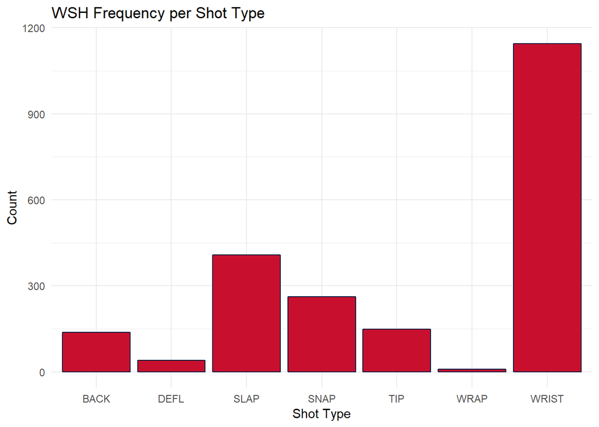

```r
wsh.type.freq = make.type.freq.plot(wsh.nnet, "#041E42", "#C8102E", "WSH")

wsh.type.freq
```

Here is how the Cawshals did with shots versus goal probability from the KNN model.

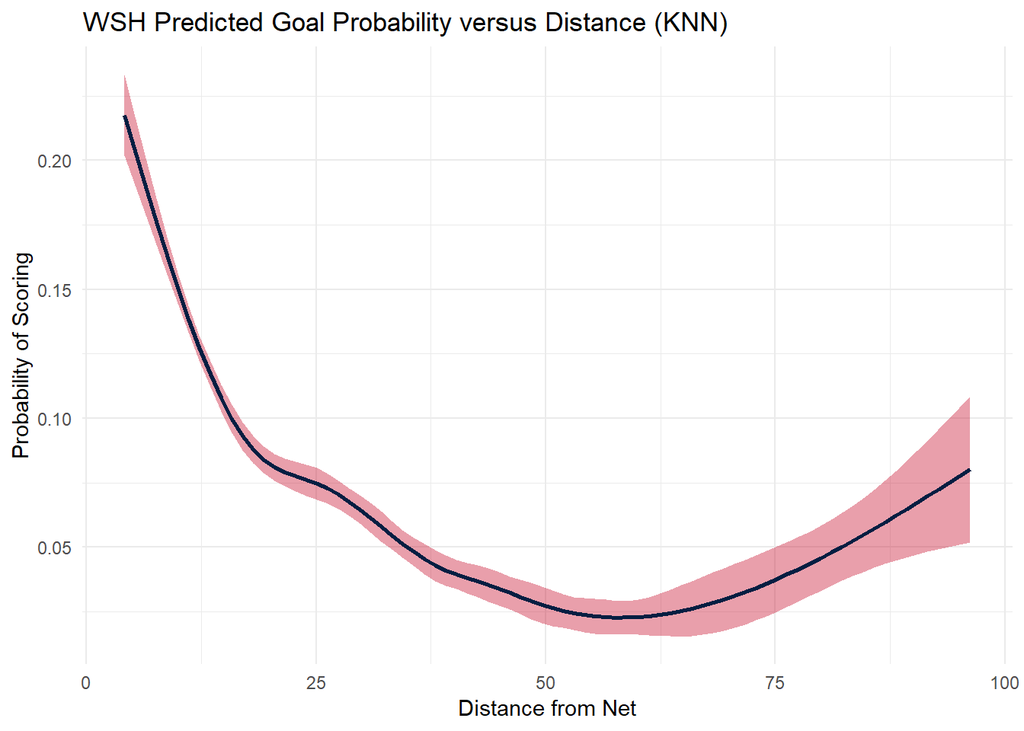

```r
wsh.knn.dist = make.knn.dist.plot(wsh.knn, "#041E42", "#C8102E", "WSH")

wsh.knn.dist
```

And now with the neural network.

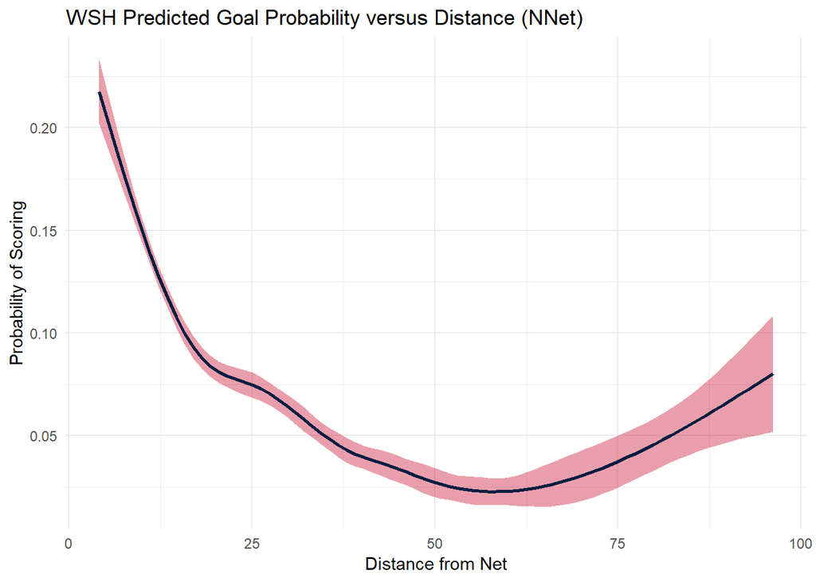

```r
wsh.nnet.dist = make.nnet.dist.plot(wsh.knn, "#041E42", "#C8102E", "WSH")

wsh.nnet.dist
```

Now let’s look at shot type versus goal probability.

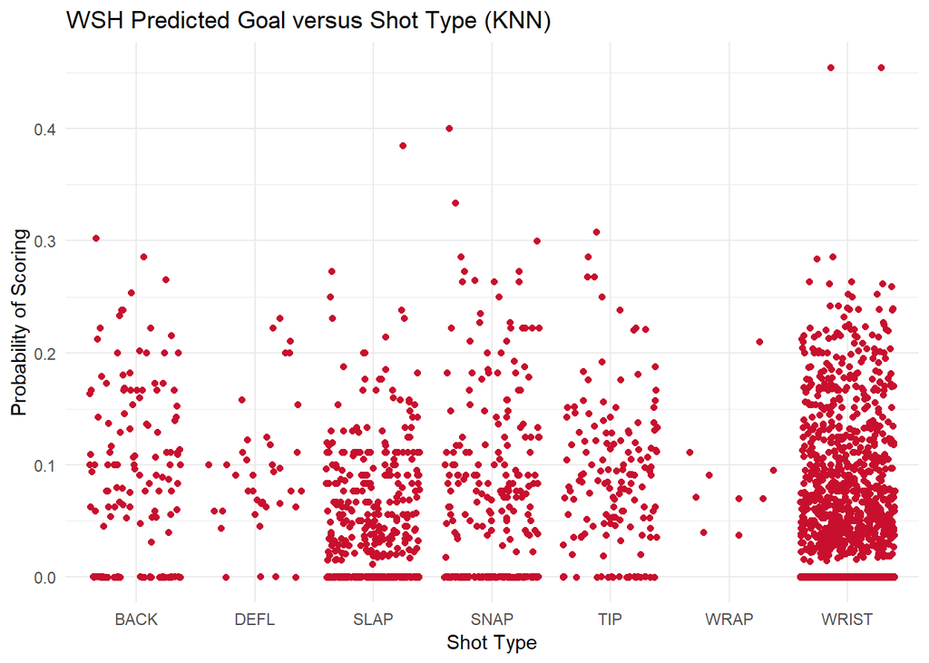

```r
wsh.knn.type = make.knn.type.plot(wsh.knn, "#041E42", "#C8102E", "WSH")

wsh.knn.type
```

And now with the neural network.

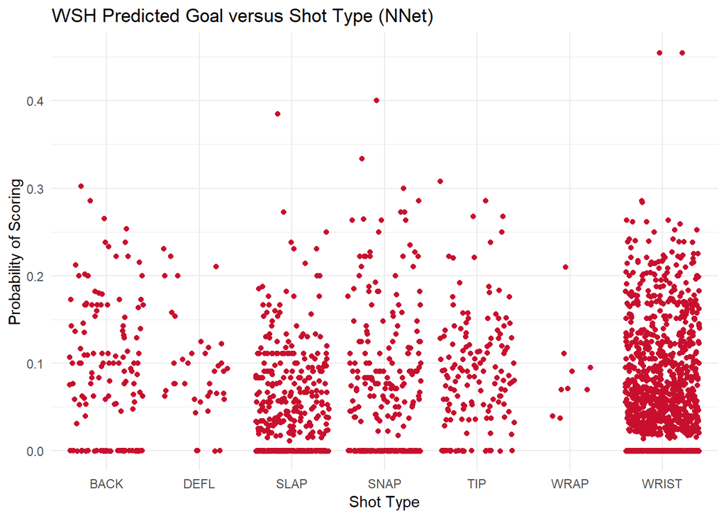

```r
wsh.nnet.type = make.nnet.type.plot(wsh.knn, "#041E42", "#C8102E", "WSH")

wsh.nnet.type
```

## Philadelphia Flyers

Let’s get our data from the Neural Network and K-Nearest Neighbors algorithms.

```r
phi.nnet = get.team.data(nnet.prediction.data, "PHI")
phi.knn = get.team.data(knn.prediction.data, "PHI")
```

Let’s just visualize our shots type data.

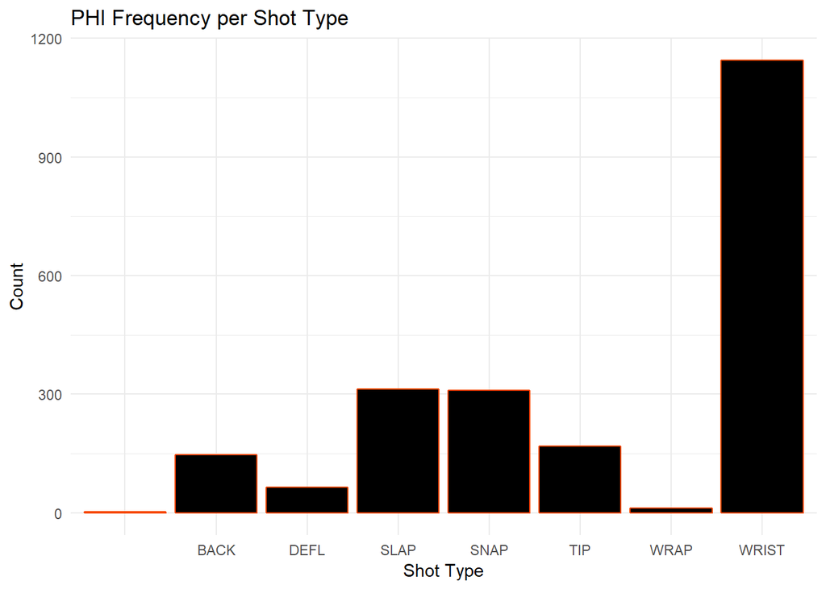

```r
phi.type.freq = make.type.freq.plot(phi.nnet, "#F74902", "#000000", "PHI")

phi.type.freq
```

Here is how the Flyers did with shots versus goal probability from the KNN model.

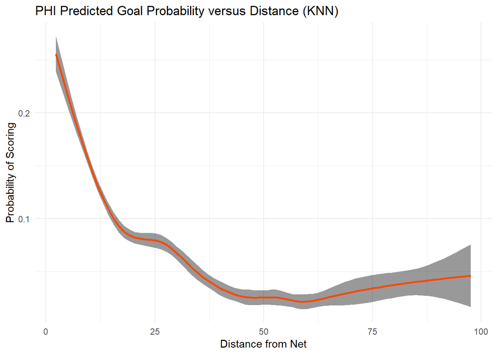

```r
phi.knn.dist = make.knn.dist.plot(phi.knn, "#F74902", "#000000", "PHI")

phi.knn.dist
```

And now with the neural network.

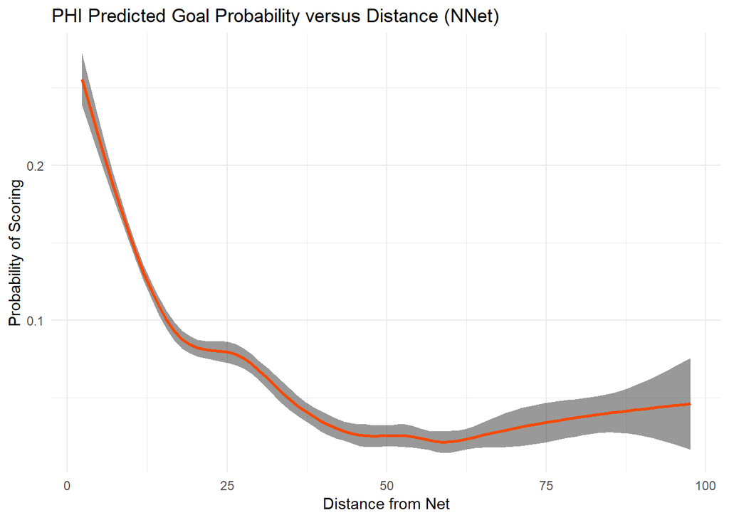

```r
phi.nnet.dist = make.nnet.dist.plot(phi.knn, "#F74902", "#000000", "PHI")

phi.nnet.dist
```

Now let’s look at shot type versus goal probability.

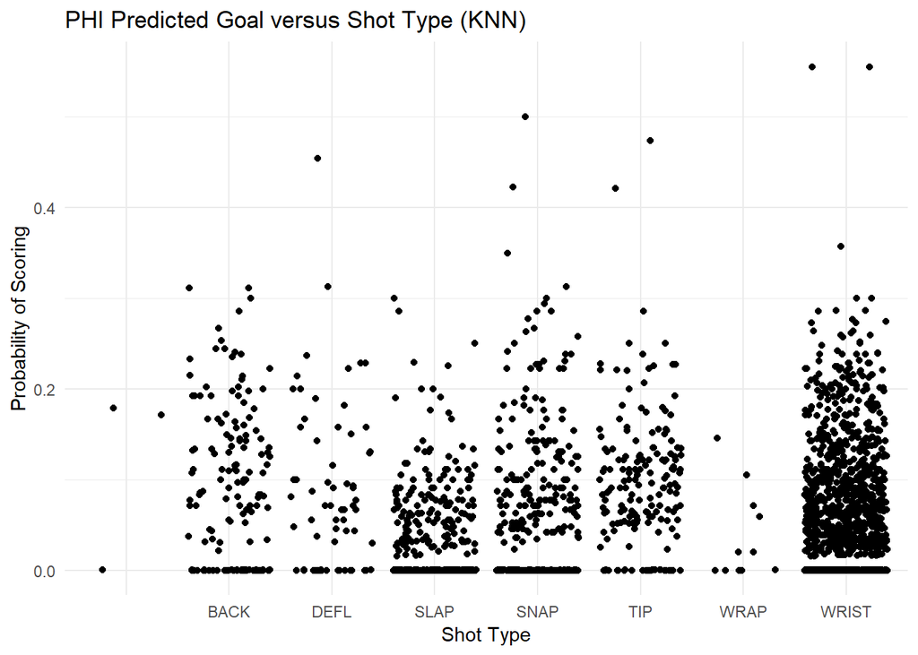

```r
phi.knn.type = make.knn.type.plot(phi.knn, "#F74902", "#000000", "PHI")

phi.knn.type
```

And now with the neural network.

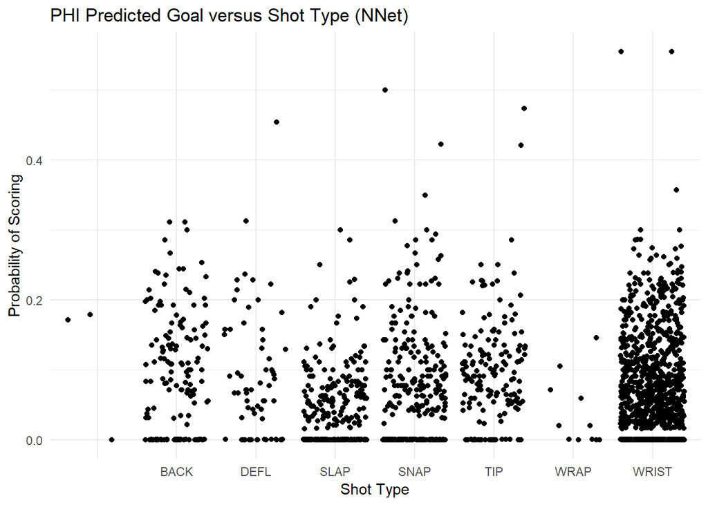

```r
phi.nnet.type = make.nnet.type.plot(phi.knn, "#F74902", "#000000", "PHI")

phi.nnet.type
```

## Boston Bruins

Let’s get our data from the Neural Network and K-Nearest Neighbors algorithms.

```r
bos.nnet = get.team.data(nnet.prediction.data, "BOS")
bos.knn = get.team.data(knn.prediction.data, "BOS")
```

Let’s just visualize our shots type data.

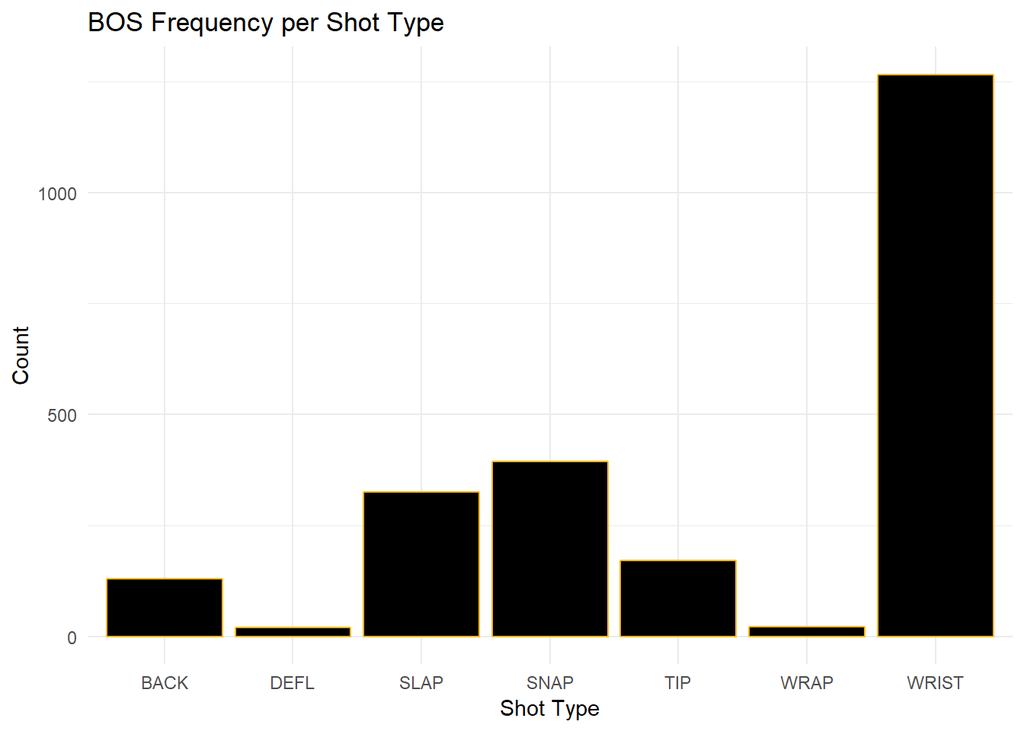

```r
bos.type.freq = make.type.freq.plot(bos.nnet, "#FFB81C", "#000000", "BOS")

bos.type.freq
```

Here is how the Bruins did with shots versus goal probability from the KNN model.

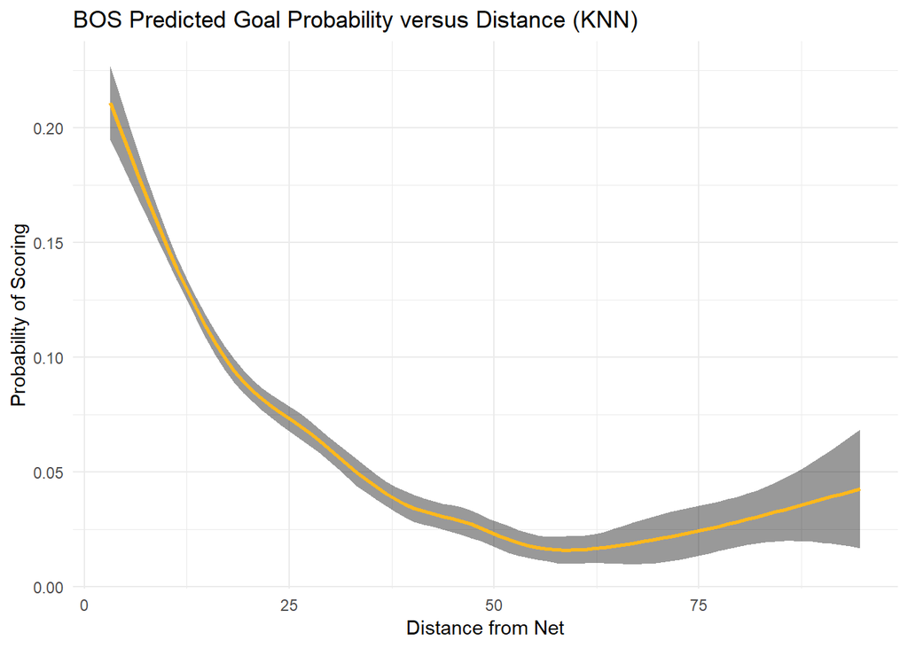

```r
bos.knn.dist = make.knn.dist.plot(bos.knn, "#FFB81C", "#000000", "BOS")

bos.knn.dist
```

And now with the neural network.

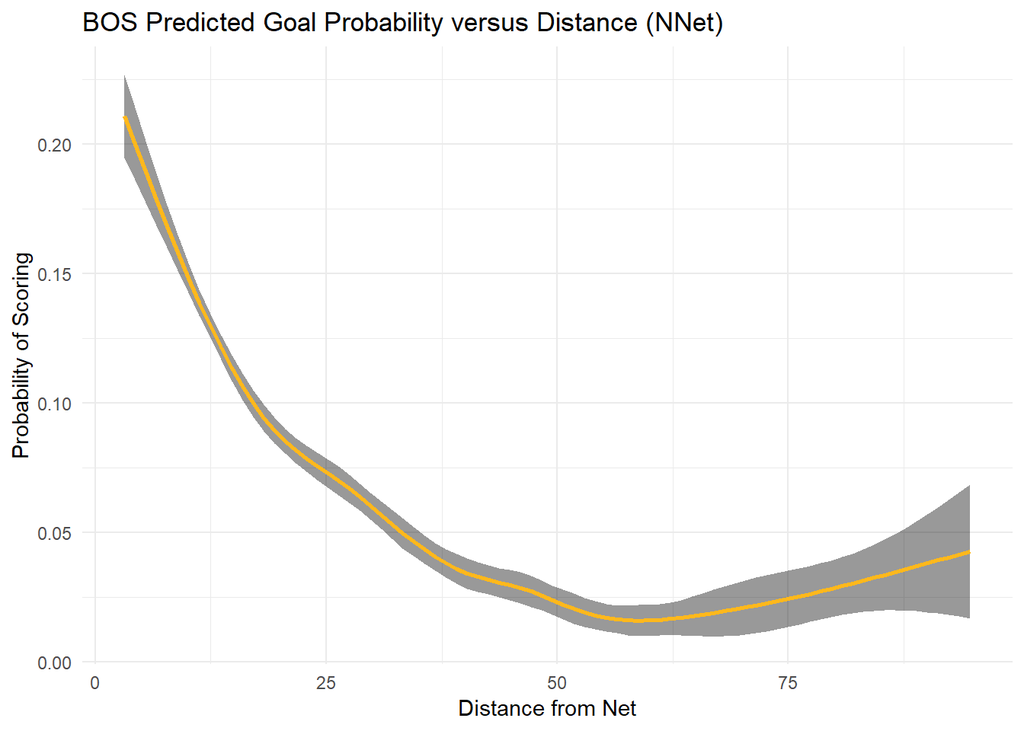

```r
bos.nnet.dist = make.nnet.dist.plot(bos.knn, "#FFB81C", "#000000", "BOS")

bos.nnet.dist
```

Now let’s look at shot type versus goal probability.

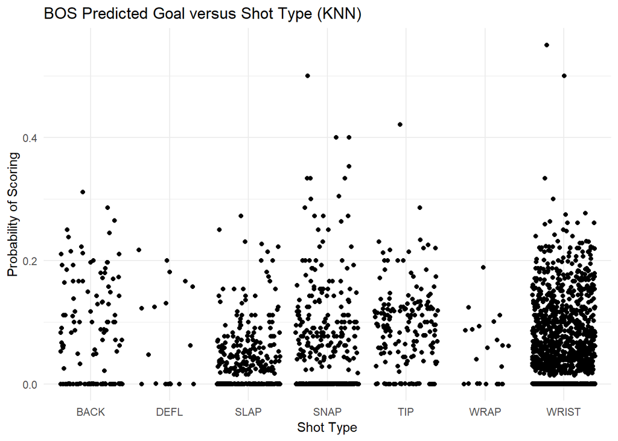

```r
bos.knn.type = make.knn.type.plot(bos.knn, "#FFB81C", "#000000", "BOS")

bos.knn.type
```

And now with the neural network.

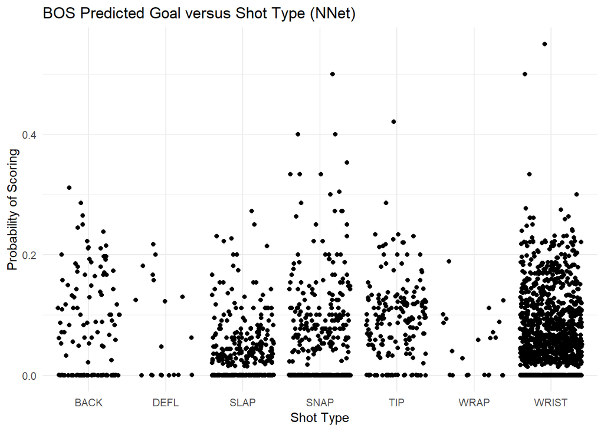

```r
bos.nnet.type = make.nnet.type.plot(bos.knn, "#FFB81C", "#000000", "BOS")

bos.nnet.type
```

## San Jose Sharks

Let’s get our data from the Neural Network and K-Nearest Neighbors algorithms.

```r
sjs.nnet = get.team.data(nnet.prediction.data, "S.J")
sjs.knn = get.team.data(knn.prediction.data, "S.J")
```

Let’s just visualize our shots type data.

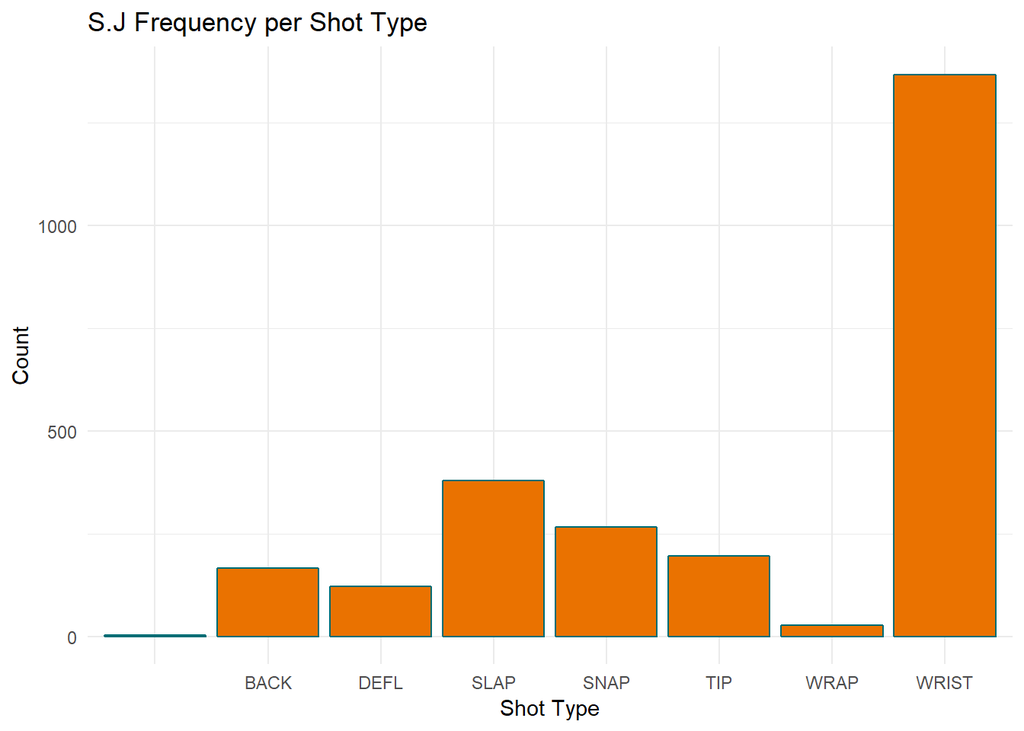

```r
sjs.type.freq = make.type.freq.plot(sjs.nnet, "#006D75", "#EA7200", "S.J")

sjs.type.freq
```

Here is how the Sharks did with shots versus goal probability from the KNN model.

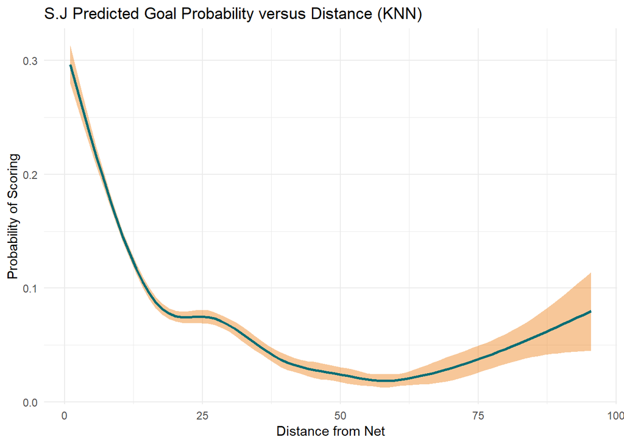

```r
sjs.knn.dist = make.knn.dist.plot(sjs.knn, "#006D75", "#EA7200", "S.J")

sjs.knn.dist
```

And now with the neural network.

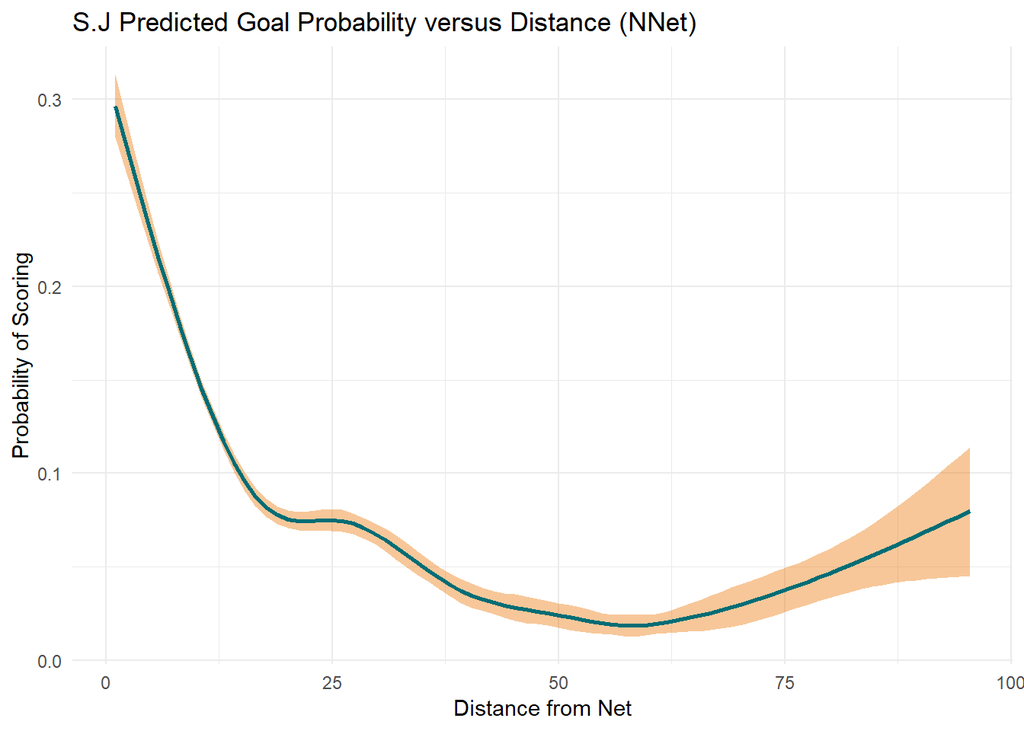

```r
sjs.nnet.dist = make.nnet.dist.plot(sjs.knn, "#006D75", "#EA7200", "S.J")

sjs.nnet.dist
```

Now let’s look at shot type versus goal probability.

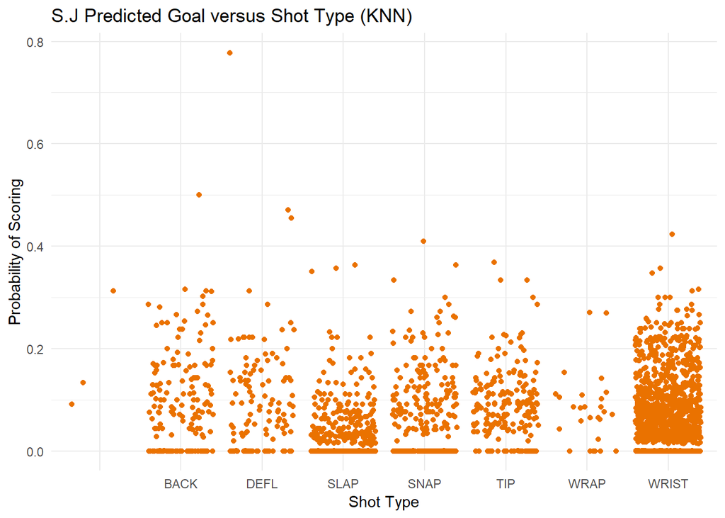

```r
sjs.knn.type = make.knn.type.plot(sjs.knn, "#006D75", "#EA7200", "S.J")

sjs.knn.type
```

And now with the neural network.

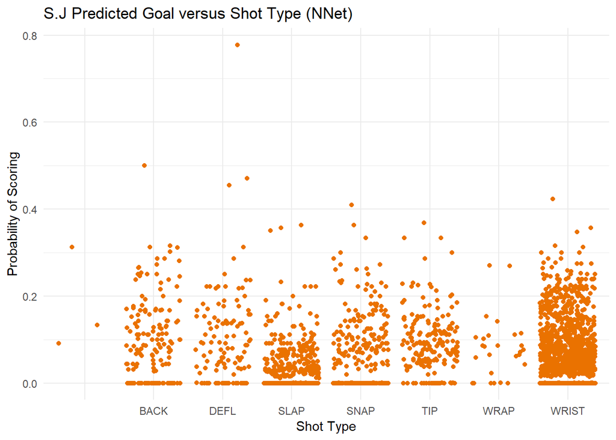

```r
sjs.nnet.type = make.nnet.type.plot(sjs.knn, "#006D75", "#EA7200", "S.J")

sjs.nnet.type
```

## Dallas Stars

Let’s get our data from the Neural Network and K-Nearest Neighbors algorithms.

```r
dal.nnet = get.team.data(nnet.prediction.data, "DAL")
dal.knn = get.team.data(knn.prediction.data, "DAL")
```

Let’s just visualize our shots type data.

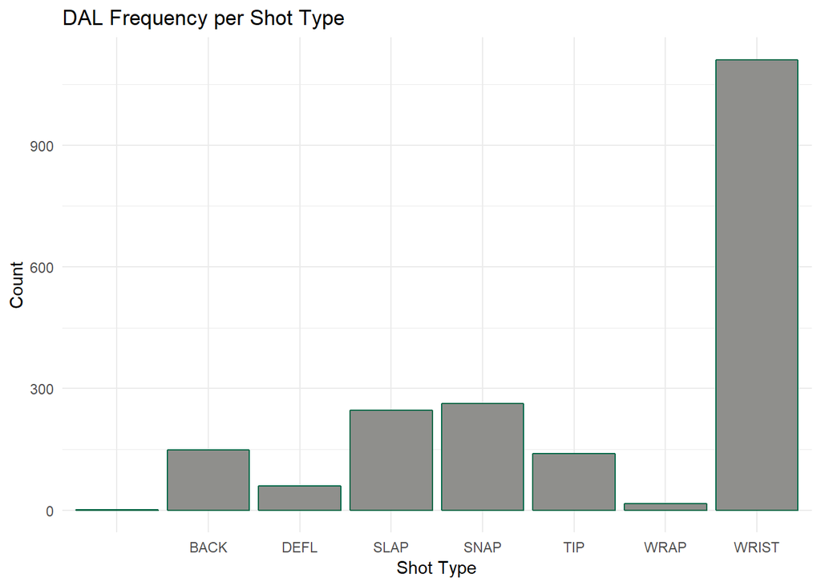

```r
dal.type.freq = make.type.freq.plot(dal.nnet, "#006847", "#8F8F8C", "DAL")

dal.type.freq
```

Here is how the Stars did with shots versus goal probability from the KNN model.

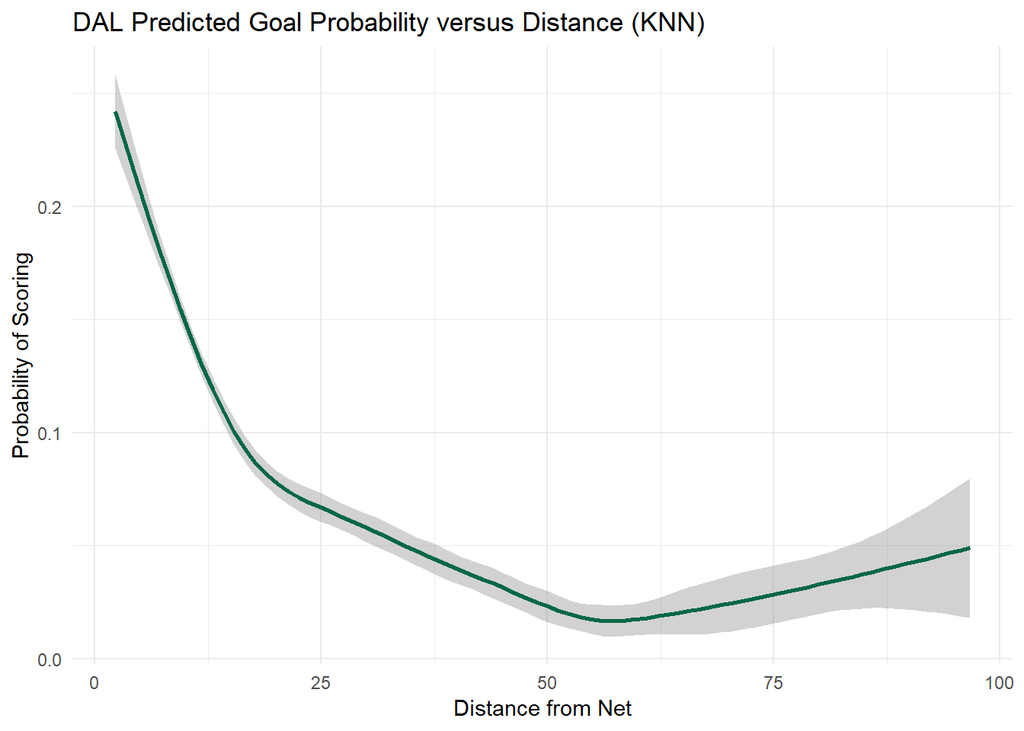

```r
dal.knn.dist = make.knn.dist.plot(dal.knn, "#006847", "#8F8F8C", "DAL")

dal.knn.dist
```

And now with the neural network.

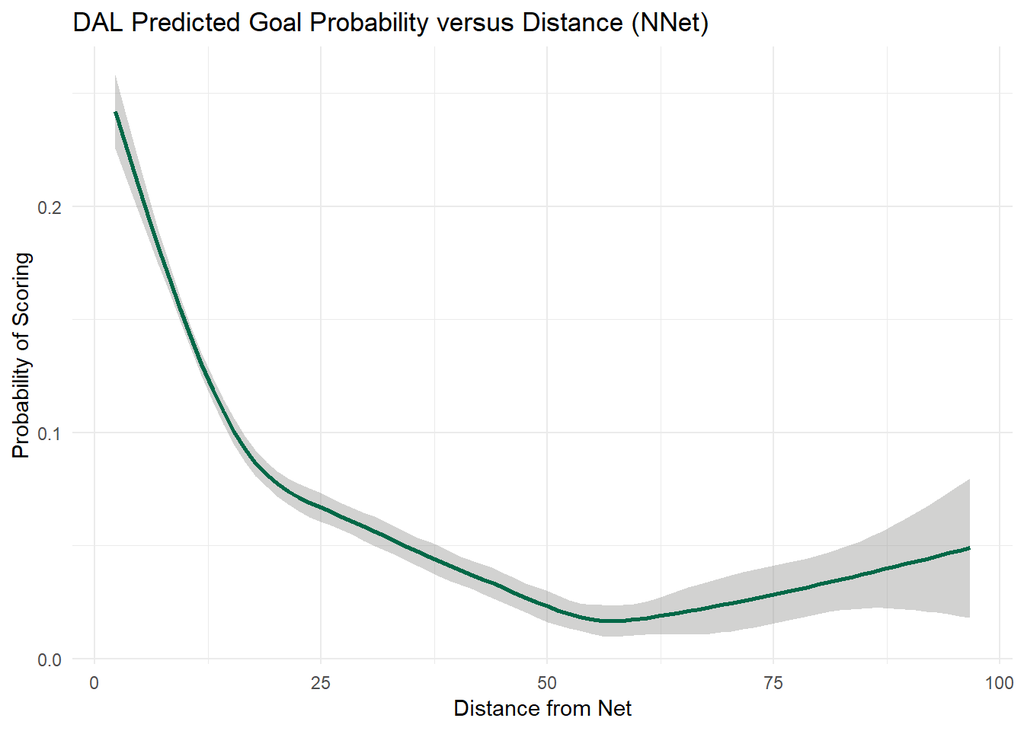

```r
dal.nnet.dist = make.nnet.dist.plot(dal.knn, "#006847", "#8F8F8C", "DAL")

dal.nnet.dist
```

Now let’s look at shot type versus goal probability.

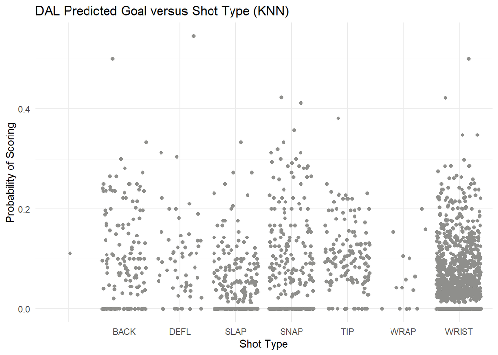

```r
dal.knn.type = make.knn.type.plot(dal.knn, "#006847", "#8F8F8C", "DAL")

dal.knn.type
```

And now with the neural network.

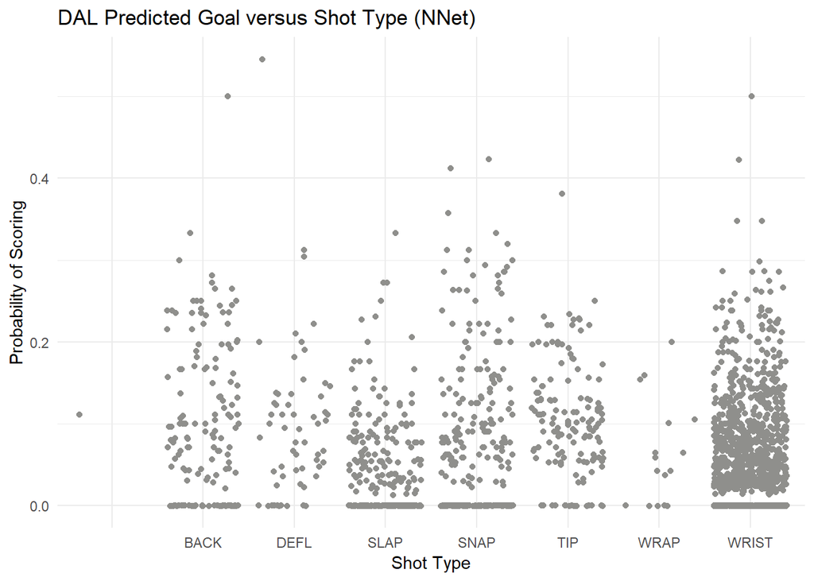

```r
dal.nnet.type = make.nnet.type.plot(dal.knn, "#006847", "#8F8F8C", "DAL")

dal.nnet.type
```